# Teste2_Karlos_Fuzzy

TESTE 2 - KARLOS

```python
#importar os pacotes necessários
import numpy as np
import skfuzzy as fuzz
import matplotlib
import matplotlib.pyplot as plt
import matplotlib.lines as mlines
from matplotlib.font_manager import FontProperties
%matplotlib inline
```

```python
intervalo1 = np.arange(0, 11, 0.1)
intervalo2 = np.arange(0, 11, 0.1)
A11 = fuzz.trimf (intervalo1, [2, 5, 7])
A21 = fuzz.trimf (intervalo1, [4, 7, 10])
A12 = fuzz.trimf (intervalo2, [1, 4, 7])
A22 = fuzz.trimf (intervalo2, [3, 6, 9])
def f1 (x,y): return 1.5*x - y
def f2 (x,y): return 1.5*y - x
```

```python
def itemA(x,y): #ISSO QUE DEVE SER CHAMADO
    w1 = min(A11[int(x*10)],A21[int(y*10)])
    w2 = max(A12[int(x*10)],A22[int(y*10)])
    return (w1*f1(x,y) + w2*f2(x,y))/(w1+w2)
```

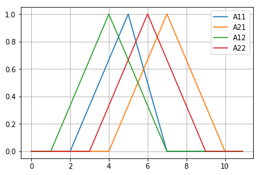

```python
fig,ax = plt.subplots()
ax.plot(intervalo1,A11,label = 'A11')
ax.plot(intervalo1,A21,label = 'A21')
ax.plot(intervalo1,A12,label = 'A12')
ax.plot(intervalo1,A22,label = 'A22')
ax.grid(True)
ax.legend(loc='upper right')
plt.show()
```

```python
itemA(5,6)
```

```
3.0000000000000004
```

```python
intervalo3 = np.arange(0, 11, 0.1)
C1 = fuzz.trimf(intervalo3, [2, 10, 10])
C2 = fuzz.trimf(intervalo3, [1, 1, 5])
def posicao(conjunto,valor):
    maisProx = 1
    aux = 0
    for i in range(conjunto.size):
        if abs(valor - conjunto[i]) < maisProx :
            maisProx = abs(valor - conjunto[i])
            aux = i
    return aux
```

```python
def itemB(x,y): #ISSO QUE DEVE SER CHAMADO
    w1 = min(A11[int(x*10)],A21[int(y*10)])
    w2 = max(A12[int(x*10)],A22[int(y*10)])
    return (w1*(posicao(C1,w1)/10) + w2*(posicao(C2,w2))/10)/(w1+w2)
```

```python
itemB(5,6)
```

```
3.52
```

Resposta item C: Não sei como analisar estes aspectos da regra. Observei que em alguns valores no Sugeno(itemA) dão negativos e acima do valor máximo de domínio.

Questao 2

```python
temp =np.arange( 0 , 46 , 1 )
pessoas = np.arange( 0 , 101 , 1 )
freq = np.arange( 0 , 101 , 1 )
```

```python
t_quente=fuzz.trimf(temp,[34,47,47])
t_moder=fuzz.trapmf(temp,[10,21,25,36])
t_frio=fuzz.trimf(temp,[0,0,15])

p_cheio=fuzz.trimf(pessoas,[60,100,100])
p_moder=fuzz.trapmf(pessoas,[20,40,60,80])
p_vazio=fuzz.trimf(pessoas,[0,0,40])

f_cheio=fuzz.trimf(pessoas,[60,100,100])
f_moder=fuzz.trapmf(pessoas,[20,40,60,80])
f_vazio=fuzz.trimf(pessoas,[0,0,40])
```

Se o tempo está frio ou quente e o ultimo passeio foi lotado então a frequencia será baixa. --- Se o tempo está friou ou quente e o ultimo passeio foi moderado ou vazio então a frequência será moderada. --- Se o tempo está moderado e o ultimo passeio foi lotado então a frenquência será moderada. --- Se o tempo está moderado e o ultimo passeio foi moderado ou vazio então a frequência será alta. ---

```python
#mandami max min
x = 30 #30 graus
y = 70 #70 pessoas
quenteOuFrio = fuzz.fuzzy_or(temp,t_quente,temp,t_frio)[1]
moderadoOuVazio = fuzz.fuzzy_or(pessoas,p_moder,pessoas,p_vazio)[1]
inputr1 = min(quenteOuFrio[x],p_cheio[y]);
inputr2 = min(quenteOuFrio[x],p_moder[y])
inputr3 = min(t_moder[x],moderadoOuVazio[y])
inputr4 = min(t_moder[x],moderadoOuVazio[y])



def novaRegra(regra, inputr):
    v = np.copy(regra)
    for j in range(v.size):
        if v[j]>inputr:
            v[j]=inputr
    return v;



#regras

R1=novaRegra(f_vazio,inputr1)
R2=novaRegra(f_moder,inputr2)
R3=novaRegra(f_moder,inputr3)
R4=novaRegra(f_cheio,inputr4)

#conclusao (juntar tudo usando operador de maximo)

RF=fuzz.fuzzy_or(pessoas,R4,pessoas,fuzz.fuzzy_or(pessoas,R3,pessoas,fuzz.fuzzy_or(pessoas,R2,pessoas,R1)[1])[1])[1]
```

```python
#defuzz
defuzz_centroid = fuzz.defuzz(pessoas, RF, 'centroid')
defuzz_centroid
```

```
62.174278573051573
```

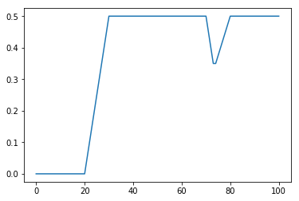

```python
plt.plot(pessoas,RF)
```

Questao 3

```python
servico=np.arange(0,11,0.1)#interlavodavariavelservico(notade0a10)
comida=np.arange(0,11,0.1)#intervalodavariavelcomida(notade0a10)
gorjeta=np.arange(0,51,0.1)#intervaloparaavariaveldesaidagorjeta

#funcoesdepertinenciaparaservico
bom=fuzz.trimf(servico,[7,10,10])
medio=fuzz.trapmf(servico,[2,4,6,8])
ruim=fuzz.trimf(servico,[0,0,5])

#funcoesdepertinenciaparaascomida
otimo=fuzz.trimf(comida,[7,10,10])
razoavel=fuzz.trapmf(comida,[2,4,6,8])
pessimo=fuzz.trimf(comida,[0,0,5])

#saida modifiquei pq tá sem sentido
alta=fuzz.trimf(gorjeta,[30,50,50])
media=fuzz.trapmf(gorjeta,[15,25,30,35])
baixa=fuzz.trimf(gorjeta,[0,0,15])
```

Servico ruim e comida ruim -> gorjeta baixa || servico medio e comida media -> gorjeta media || servico bom e comida boa -> gorjeta boa.

```python
qualidadeComida = 6.1
qualidadeServico = 8.4

regra1 = min(ruim[60],pessimo[83])
regra2 = min(medio[60],razoavel[83])
regra3 = min(bom[60],otimo[83])
regra4 = min(ruim[60],otimo[83])
regra5 = min(medio[60],pessimo[83])
regra6 = min(bom[60],razoavel[83])
regra7 = min(ruim[60],razoavel[83])
regra8 = min(medio[60],otimo[83])
regra9 = min(bom[60],pessimo[83])

def novaRegraMin(regra, inputr):
    v = np.copy(regra)
    for j in range(v.size):
        if v[j]>inputr:
            v[j]=inputr
    return v;

R1 = novaRegraMin(baixa,regra1)
R2 = novaRegraMin(media,regra2)
R3 = novaRegraMin(alta,regra3)
R4 = novaRegraMin(baixa,regra4)
R5 = novaRegraMin(baixa,regra5)
R6 = novaRegraMin(media,regra6)
R7 = novaRegraMin(baixa,regra7)
R8 = novaRegraMin(media,regra8)
R9 = novaRegraMin(baixa,regra9)

RF=fuzz.fuzzy_or(gorjeta,R1,gorjeta,fuzz.fuzzy_or(gorjeta,R2,gorjeta,fuzz.fuzzy_or(gorjeta,R3,gorjeta,fuzz.fuzzy_or(gorjeta,R4,gorjeta,fuzz.fuzzy_or(gorjeta,R5,gorjeta,fuzz.fuzzy_or(gorjeta,R6,gorjeta,fuzz.fuzzy_or(gorjeta,R7,gorjeta,fuzz.fuzzy_or(gorjeta,R8,gorjeta,R9)[1])[1])[1])[1])[1])[1])[1])[1]
defuzz_centroid = fuzz.defuzz(gorjeta, RF, 'centroid')
defuzz_centroid
```

```
25.506503168917103
```

```python
def novaRegraProd(regraX, regraY):
    v = np.zeros(regraX.size)
    for j in range(regraX.size):
        v[j] = regraX[j] * regraY[j]
    return v;

R1 = novaRegraProd(ruim,pessimo)
R2 = novaRegraProd(medio,razoavel)
R3 = novaRegraProd(bom,otimo)

RF=fuzz.fuzzy_or(servico,R3,servico,fuzz.fuzzy_or(servico,R2,servico,R1)[1])[1]
defuzz_centroid = fuzz.defuzz(servico, RF, 'centroid')
defuzz_centroid
```

```
4.7527283160346379
```

OBSERVACAO: nao sei como fazer com que o resultado do Mamdani ficar no dominio de gorjeta

Consegui!

```python
#tentativa
regra1 = min(ruim[60],pessimo[83])
regra2 = min(medio[60],razoavel[83])
regra3 = min(bom[60],otimo[83])
regra4 = min(ruim[60],otimo[83])
regra5 = min(medio[60],pessimo[83])
regra6 = min(bom[60],razoavel[83])
regra7 = min(ruim[60],razoavel[83])
regra8 = min(medio[60],otimo[83])
regra9 = min(bom[60],pessimo[83])

def novaRegraProd(regraX, valor):
    v = np.zeros(regraX.size)
    for j in range(regraX.size):
        v[j] = regraX[j] * valor
    return v;

R1 = novaRegraProd(baixa,regra1)
R2 = novaRegraProd(media,regra2)
R3 = novaRegraProd(alta,regra3)
R4 = novaRegraProd(baixa,regra4)
R5 = novaRegraProd(baixa,regra5)
R6 = novaRegraProd(media,regra6)
R7 = novaRegraProd(baixa,regra7)
R8 = novaRegraProd(media,regra8)
R9 = novaRegraProd(baixa,regra9)

RF=fuzz.fuzzy_or(gorjeta,R1,gorjeta,fuzz.fuzzy_or(gorjeta,R2,gorjeta,fuzz.fuzzy_or(gorjeta,R3,gorjeta,fuzz.fuzzy_or(gorjeta,R4,gorjeta,fuzz.fuzzy_or(gorjeta,R5,gorjeta,fuzz.fuzzy_or(gorjeta,R6,gorjeta,fuzz.fuzzy_or(gorjeta,R7,gorjeta,fuzz.fuzzy_or(gorjeta,R8,gorjeta,R9)[1])[1])[1])[1])[1])[1])[1])[1]
defuzz_centroid = fuzz.defuzz(gorjeta, RF, 'centroid')
defuzz_centroid
```

```
26.000000000000007
```

Questao 4

Resposta item A: Sugeno pois são dadas as funcoes para z. Se as funcoes forem monotonas tsukamoto tbm pode ser bom

```python
#item B
def z1 (p,ns): return (p/100) + (ns/5)
def z2 (p,ns): return (p/75) + (ns/2)
def z3 (p,ns): return (p/30) + (ns/2)

#dominio
peso=np.arange(0,21,0.1)
ns=np.arange(0,10,0.1)


muito_leve=fuzz.trimf(peso,[0,0,7])
leve=fuzz.trimf(peso,[5,10,16])
pesado=fuzz.trimf(peso,[13,20,20])

muito_sujo=fuzz.trimf(ns,[7,10,10])
sujo=fuzz.trapmf(ns,[2,4,6,8])
quase_limpo=fuzz.trimf(ns,[0,0,5])

Epeso = 15
Esuj = 6

w1=min(muito_leve[(Epeso*10)-1],quase_limpo[(Esuj*10)-1])
w2=min(leve[(Epeso*10)-1],sujo[(Esuj*10)-1])
w3=min(pesado[(Epeso*10)-1],muito_sujo[(Esuj*10)-1])

qtdDetergente = ( w1*z1(Epeso,Esuj) + w2*z2(Epeso,Esuj) + w3*z3(Epeso,Esuj) ) / (w1 + w2 + w3)
```

```python
qtdDetergente
```

```
3.2000000000000002
```

AVISO: Discutimos que essa parte questão tá modelada errada, estão muito altos os valores

```python
#item C - TSUKAMOTO
Epeso = 15
Esuj = 6
intervalo3= np.arange(1,30.1,0.1)
C1=fuzz.gaussmf(intervalo3,30,15)#variavelfuzzy1
C2=fuzz.gaussmf(intervalo3,0,15)#variavelfuzzy2

w1=min(muito_leve[(Epeso*10)-1],quase_limpo[(Esuj*10)-1])
w2=min(leve[(Epeso*10)-1],sujo[(Esuj*10)-1])
w3=min(pesado[(Epeso*10)-1],muito_sujo[(Esuj*10)-1])

def posicao(conjunto,valor):
    maisProx = 1
    aux = 0
    for i in range(conjunto.size):
        if abs(valor - conjunto[i]) < maisProx :
            maisProx = abs(valor - conjunto[i])
            aux = i
    return aux

z1 = posicao(C2,w1)/10
z2 = posicao(C2,w2)/10
z3 = posicao(C1,w3)/10

qtdDetergente = ( w1*z1 + w2*z2 + w3*z3 ) / (w1 + w2 + w3)
qtdDetergente
```

```
26.600000000000001
```

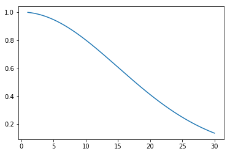

```python
plt.plot(intervalo3,C2)
```

Questao 5

```python
E_P=np.arange(0,101,0.1)
E_I=np.arange(0,101,0.1)
Agres=np.arange(0,5,0.1)

prox_morte=fuzz.trimf(E_P,[0,0,50])
bem=fuzz.trimf(E_P,[14,50,83])
otimo=fuzz.trimf(E_P,[50,100,100])
```

Eu prox_morte e inimigo bem ou otimo -> agressividade 0 || Eu prox_morte ou bem e inimigo otimo -> agressividade 0 || Eu bem e inimigo bem ->agressividade[1:3] || Eu otimo e inimigo otimo -> agressividade[1:3] || Eu otimo e inimigo bem ou prox_morte -> agressividade [3:4] || eu bem ou otimo e inimigo prox_morte -> agressividade [3:4]

```python
ag_baixa = fuzz.trimf(Agres, [0,0,1])
ag_media = fuzz.trimf(Agres, [1.1,2,2.9])
ag_alta = fuzz.trimf(Agres, [3,4,4])

fracoOuBem = fuzz.fuzzy_or(E_P,prox_morte,E_P,bem)[1]
bemOuOtimo = fuzz.fuzzy_or(E_P,bem,E_P,otimo)[1]

Pers = 73
Inim = 71

regra1 = min(prox_morte[Pers*10-1],bemOuOtimo[Inim*10-1])
regra2 = min(fracoOuBem[Pers*10-1],otimo[Inim*10-1])
regra3 = min(bem[Pers*10-1],bem[Inim*10-1])
regra4 = min(otimo[Pers*10-1],otimo[Inim*10-1])
regra5 = min(otimo[Pers*10-1],fracoOuBem[Inim*10-1])
regra6 = min(bemOuOtimo[Pers*10-1],prox_morte[Inim*10-1])

def novaRegraMin(regra, inputr):
    v = np.copy(regra)
    for j in range(v.size):
        if v[j]>inputr:
            v[j]=inputr
    return v;

R1 = novaRegraMin(ag_baixa,regra1)
R2 = novaRegraMin(ag_baixa,regra2)
R3 = novaRegraMin(ag_media,regra3)
R4 = novaRegraMin(ag_media,regra4)
R5 = novaRegraMin(ag_alta,regra5)
R6 = novaRegraMin(ag_alta,regra6)

RF = fuzz.fuzzy_or(Agres,R6,Agres,fuzz.fuzzy_or(Agres,R5,Agres,fuzz.fuzzy_or(Agres,R4,Agres,fuzz.fuzzy_or(Agres,R3,Agres,fuzz.fuzzy_or(Agres,R2,Agres,R1)[1])[1])[1])[1])[1]
defuzz_centroid = fuzz.defuzz(Agres, RF, 'centroid')
defuzz_centroid
```

```
2.0883322443589409
```

Funções do Sugeno, analise os casos extremos para entender o comportamento da função

```python
def zAlta (Pe,In): return 3 + (Pe-In)/100
def zMedia (Pe,In): return 2 - (In-Pe)/100
def zBaixa (Pe,In): return 0.5 - (In-Pe)/200
```

Eu prox_morte e inimigo bem ou otimo -> C1 || Eu prox_morte ou bem e inimigo otimo -> C1 || Eu bem e inimigo bem ->agressividade C2 || Eu otimo e inimigo otimo -> C2 || Eu prox_morte e inimigo prox_morte -> C2 || Eu otimo e inimigo bem ou prox_morte -> C3 || eu bem ou otimo e inimigo prox_morte -> C3

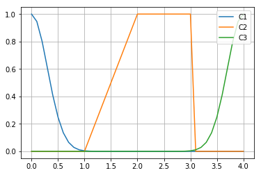

```python
intervalo5 = np.arange(0,4.1,0.1)
C1=fuzz.gaussmf(intervalo5,0,0.3)
C2=fuzz.trapmf(intervalo5,[1,2,3,3])
C3=fuzz.gaussmf(intervalo5,4,0.3)
fig,ax = plt.subplots()

ax.plot(intervalo5,C1,label = 'C1')
ax.plot(intervalo5,C2,label = 'C2')
ax.plot(intervalo5,C3,label = 'C3')
ax.grid(True)
ax.legend(loc='upper right')
plt.show()
```